# Case study D: digit recognition with scBubbletree

SK

This vignette introduces `scBubbletree`, a transparent workflow for exploration of single cell RNA-seq data. To run this vignette we need a few R-packages:

```r
library(scBubbletree)
library(ggrepel)
library(umap)
```

## Data

For this case study we will **not** explore single cell RNA-seq data. Instead, we will look into the **digits** dataset. The data contains 64 feature (8x8 pixel values in the range 0 to 16) for 5620 images.

```r
# .. _digits_dataset:
#
# Optical recognition of handwritten digits dataset
# --------------------------------------------------
#
# Data Set Characteristics:
#
#     :Number of Instances: 5620
#     :Number of Attributes: 64
#     :Attribute Information: 8x8 image of integer pixels in the range 0..16.
#     :Missing Attribute Values: None
#     :Creator: E. Alpaydin (alpaydin '@' boun.edu.tr)
#     :Date: July; 1998
#
# This is a copy of the test set of the UCI ML hand-written digits datasets
# https://archive.ics.uci.edu/ml/datasets/Optical+Recognition+of+Handwritten+Digits
#
# The data set contains images of hand-written digits: 10 classes where
# each class refers to a digit.
#
# Preprocessing programs made available by NIST were used to extract
# normalized bitmaps of handwritten digits from a preprinted form. From a
# total of 43 people, 30 contributed to the training set and different 13
# to the test set. 32x32 bitmaps are divided into nonoverlapping blocks of
# 4x4 and the number of on pixels are counted in each block. This generates
# an input matrix of 8x8 where each element is an integer in the range
# 0..16. This reduces dimensionality and gives invariance to small
# distortions.
#
# For info on NIST preprocessing routines, see M. D. Garris, J. L. Blue, G.
# T. Candela, D. L. Dimmick, J. Geist, P. J. Grother, S. A. Janet, and C.
# L. Wilson, NIST Form-Based Handprint Recognition System, NISTIR 5469,
# 1994.
#
# .. topic:: References
#
#   - C. Kaynak (1995) Methods of Combining Multiple Classifiers and Their
#     Applications to Handwritten Digit Recognition, MSc Thesis, Institute of
#     Graduate Studies in Science and Engineering, Bogazici University.
#   - E. Alpaydin, C. Kaynak (1998) Cascading Classifiers, Kybernetika.
#   - Ken Tang and Ponnuthurai N. Suganthan and Xi Yao and A. Kai Qin.
#     Linear dimensionalityreduction using relevance weighted LDA. School of
#     Electrical and Electronic Engineering Nanyang Technological University.
#     2005.
#   - Claudio Gentile. A New Approximate Maximal Margin Classification
#     Algorithm. NIPS. 2000.
```

The `scBubbletree` workflow performs the following steps:

1. determine number of clusters $k$
2. $k$-means clustering
3. hierarchical organization of clusters (bubbles)
4. visualization

### 1. determining the number of clusters $k$

How many clusters (digits) are there are in the data? For this we will use the function `get_k` for data-driven inference of $k$ based on the Gap statistic and the within-cluster sum of squares (WCSS).

The function `get_k` performs $B$ bootstrapping iterations. k-means clustering is performed in each iteration using as input matrix $A$ an a vector of $k$ values. We can use the full matrix $A$ (this is recommended for smaller datasets) or a subset of the rows (cells) of $A$ controlled by the parameter `cv_prop` (recommended for large datasets). In each iteration we compute the Gap statistic and WCSS for all $k$s.

Lets run `get_k` now:

```r
b <- get_k(B = 5,
           cv_prop = 0.5,
           ks = seq(from = 1, to = 30, by = 1),
           x = digits,
           n_start = 100,
           iter_max = 200,
           kmeans_algorithm = "MacQueen",
           cores = 20,
           mini_output = F)
```

```
FALSE boot: 1  : 1) clustering, 2) gap-stat, 3) WCSS.
FALSE boot: 2  : 1) clustering, 2) gap-stat, 3) WCSS.
FALSE boot: 3  : 1) clustering, 2) gap-stat, 3) WCSS.
FALSE boot: 4  : 1) clustering, 2) gap-stat, 3) WCSS.
FALSE boot: 5  : 1) clustering, 2) gap-stat, 3) WCSS.
```

As expected, the Gap statistic and WCSS curves appear to have at $k\approx10$. Lets use a value of $k$ slightly larger than 10, e.g. $k=15$ for clustering. Means and 95% confidence intervals are shown for the metrics (panels) at each $k$.

```r
g0 <- ggplot(data = b$gap_stats_summary)+
  geom_point(aes(x = k, y = gap_mean), size = 1)+
  geom_errorbar(aes(x = k, y = gap_mean, ymin = L95, ymax = H95), width = 0.1)+
  ylab(label = "Gap")|
ggplot(data = b$wcss_stats_summary)+
  geom_point(aes(x = k, y = wcss_mean), size = 1)+
  geom_errorbar(aes(x = k, y = wcss_mean, ymin = L95, ymax = H95), width = 0.1)+
  ylab(label = "WCSS")+
  scale_y_log10()+
  annotation_logticks(base = 10, sides = "l")
```

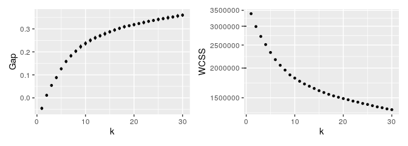

```r
g0
```

### 2. $k$-means clustering

We will use $k=15$ and $A$ as input for k-means clustering with the function kmeans (R-package stats). We will use MacQueen’s k-means variant, which will perform $n_{start} = 1000$ (default in scBubbletree) random starts and a maximum number of iterations $iter_{max} = 300$.

**Important remark**: for smaller datasets (e.g. $n<100000$) the defaults $n_{start}=1000$ and $n_{iter} = 300$ are set to unnecessarily high values, however for larger datasets this is necessary to make sure that k-means converges.

### 3. hierarchical grouping

After the clustering is complete we will organize the bubbles in a natural hierarchy. For this we perform $B$ bootstrap iterations (default $B=100$). In iteration $b$ the algorithm draws a random subset of $N_{eff}$ (default $N_{eff}=100$) cells with replacement from each cluster and computes the average inter-cluster Euclidean distance. This data is used to populate the distance matrix ($D^{k\times k}_b$), which is provided as input for hierarchical clustering with average linkage to generate a hierarchical clustering dendrogram $H_b$.

The collection of distance matrices that are computed during $B$ iterations are used to compute a consensus (average) distance matrix $\hat{D}^{k\times k}$ and a corresponding consensus hierarchical dendrogram (bubbletree; $\hat{H}$). The collection of dendrograms are used to quantify the robustness of the bubbletree topology, i.e. to count the number of times each branch in the bubbletree is found among the topologies of the bootstrap dendrograms. Branches can have has variable degrees of support ranging between 0 (no support) and $B$ (complete support). Distances between bubbles (inter-bubble relationships) are described quantitatively in the bubbletree as sums of branch lengths.

Steps 2. and 3. are performed next

```r
k15 <- get_bubbletree(x = digits,
                     k = 15,
                     seed = 1234,
                     cores = 1,
                     B = 200,
                     N_eff = 200,
                     round_digits = 1,
                     show_simple_count = F,
                     kmeans_algorithm = "MacQueen")
```

```
FALSE Clustering ...
FALSE Bubbletree construction ...
```

… and plot the bubbletree

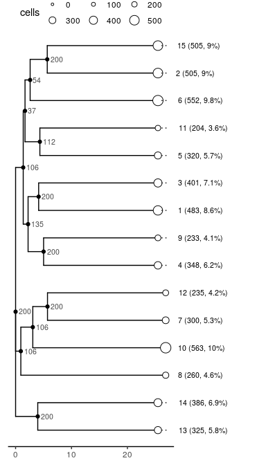

```r
k15$tree
```

### 4. visualization

### attaching categorical features (digits labels)

Relative frequencies of digit labels across different bubbles (columns integrate to 100%). We will use a black and white color scale by setting `tile_bw=T`.

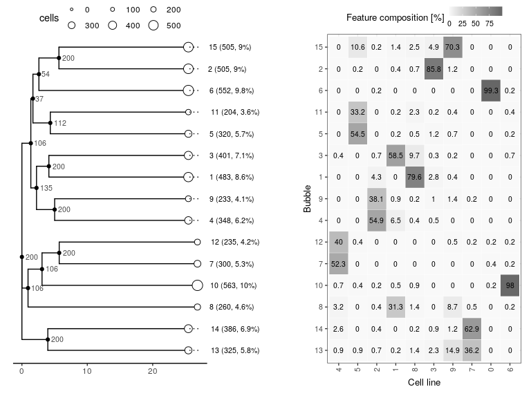

```r
w1 <- get_cat_tiles(btd = k15,
                    f = as.character(labels),
                    integrate_vertical = T, # relative frequency of labels
                    round_digits = 1,
                    show_hclust = F,
                    disable_hclust = F,
                    x_axis_name = 'Cell line',
                    rotate_x_axis_labels = T,
                    tile_text_size = 2.75,
                    tile_bw = T)

(k15$tree|w1$plot)+
  patchwork::plot_layout(widths = c(1, 1))
```

Within-bubble relative frequencies of digit labels (rows integrate to 100%).

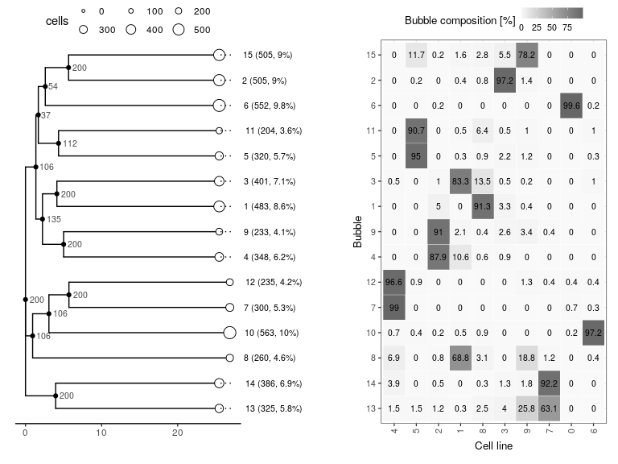

```r
w2 <- get_cat_tiles(btd = k15,
                    f = as.character(labels),
                    integrate_vertical = F, # within-bubble rel. freq. of labels
                    round_digits = 1,
                    show_hclust = F,
                    disable_hclust = F,
                    x_axis_name = 'Cell line',
                    rotate_x_axis_labels = T,
                    tile_text_size = 2.75,
                    tile_bw = T)

(k15$tree|w2$plot)+
  patchwork::plot_layout(widths = c(1, 1))
```

# Average digit image in each bubble

Lets compute the average pixel values using the digit data in each bubble and ‘attach’ this data to the bubbletree

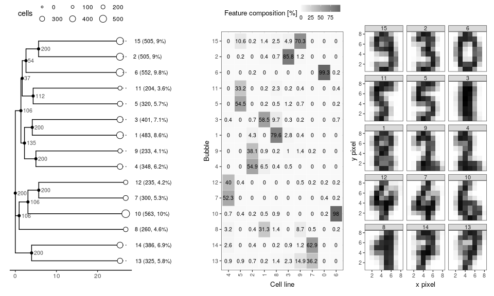

## UMAP

Generating 2D UMAP plots is a standard first step in scRNA-seq data analysis. Lets do this now

```r
umap_2 <- umap::umap(d = digits)

umap_2_data <- data.frame(UMAP_1 = umap_2$layout[, 1],
                          UMAP_2 = umap_2$layout[, 2],
                          bubble = k15$cluster,
                          digits = labels)
```

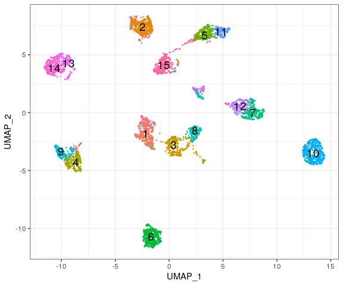

## Are local/global distances between cells preserved by UMAP?

Local cell distances appear to be adequately recovered, long-range distances are not. Gray points are intra-bubble distances and black points are inter-bubble distances.

```r
get_d <- function(A, U_A, T_A, B, verbose=F) {

  get_euc <- function(x, y) {
    return(sqrt(sum((x-y)^2)))
  }

  get_pair_euc <- function(x, A, U_A, T_A) {

    if(x %% 1000 == 0) {
      cat(x, "\n")
    }

    j <- sample(x = 1:nrow(A), size = 2, replace = T)
    a_euc <- get_euc(A[j[1],], A[j[2],])
    u_euc <- get_euc(U_A[j[1],], U_A[j[2],])
    t_euc <- get_euc(T_A[j[1],], T_A[j[2],])

    return(data.frame(a_euc = a_euc,
                      u_euc = u_euc,
                      t_euc = t_euc,
                      i = j[1],
                      j = j[2]))
  }

  o <- lapply(X = 1:B,
              FUN = get_pair_euc,
              A = A,
              U_A = U_A,
              T_A = T_A)

  o <- do.call(rbind, o)
  return(o)
}
```

```r
pair_dist <- get_d(B = 10^4,
                   A = digits,
                   U_A = umap_2_data[, c("UMAP_1", "UMAP_2")],
                   T_A = umap_2_data[, c("UMAP_1", "UMAP_2")],
                   verbose = F)

pair_dist$i_cell <- k15$cluster[pair_dist$i]
pair_dist$j_cell <- k15$cluster[pair_dist$j]

pair_dist$i_label <- labels[pair_dist$i]
pair_dist$j_label <- labels[pair_dist$j]

pair_dist$same_cell <- ifelse(test = pair_dist$i_cell==pair_dist$j_cell,
                              yes = "w", no = "b")
pair_dist$same_label <- ifelse(test = pair_dist$i_label==pair_dist$j_label,
                               yes = "w", no = "b")
```

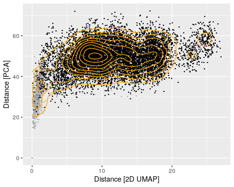

```r
ggplot(data = pair_dist)+
  geom_point(aes(y = a_euc, x = u_euc, col = same_cell), size = 0.25)+
  geom_density_2d(aes(y = a_euc, x = u_euc), col = "orange")+
  ylab(label = "Distance [PCA]")+
  xlab(label = "Distance [2D UMAP]")+
  scale_color_manual(values = c("black", "darkgray"))+
  theme(legend.position = "none")
```